# python-data-analysis-project

## Introduction:

The data I used is from the public data repository earthdata.nasa.gov, and is titled: ABoVE: Synthesis of Burned and Unburned Forest Site Data, AK and Canada, 1983-2016 The questions I asked when analyzing this data:

1. How does the average total carbon combusted vary across different ecoregions?
2. What is the relationship between stand age and total carbon combusted?
3. What is the distribution of total carbon combusted across all sites?
4. How do fire danger indices, such as the Fire Weather Index (FWI), change over time?
5. What are the temporal trends in total carbon combusted over the years?
6. How do soil carbon levels relate to total carbon combusted during fires?
7. What is the average stand age across different ecoregions?
8. What are the correlations between key variables such as total carbon combusted, stand age, and fire weather indices?
9. How does the burn depth impact soil carbon content?
10. How has precipitation varied over time in areas affected by fires?

```python
import pandas as pd
import numpy as np
```

```python
# Load the datasets into pandas DataFrames
burned_plot_data = pd.read_csv("AK_CA_Burned_Plot_Data_1983_2016.csv")
soil_profile_data = pd.read_csv("AK_CA_Soil_Profile_Synthesis.csv")
```

```python
burned_plot_data.head()
```

|  | project_id | project_name | treatment | site | burn_name | burn_year | ecoregion_name_l2 | latitude | longitude | accuracy_horizontal | ... | temperature | relative_humidity | wind_speed | drought_code | drought_moisture_code | fine_fuel_moisture_code | initial_spread_index | buildup_index | fire_weather_index | daily_severity_rank |
| --- | --- | --- | --- | --- | --- | --- | --- | --- | --- | --- | --- | --- | --- | --- | --- | --- | --- | --- | --- | --- | --- |
| 0 | NWT_BCKE.sf.1 | NWT_BCKE | burn | Jan-94 | NaN | 1994 | Taiga Plains | 61.5271 | -117.2279 | -9999.0 | ... | -9999.0 | -9999.0 | -9999.0 | -9999.0 | -9999.0 | -9999.0 | -9999.0 | -9999.0 | -9999.0 | -9999.0 |
| 1 | NWT_BCKE.sf.2 | NWT_BCKE | burn | Jan-94 | 1994 | 1994 | Taiga Plains | 61.5272 | -117.2282 | -9999.0 | ... | -9999.0 | -9999.0 | -9999.0 | -9999.0 | -9999.0 | -9999.0 | -9999.0 | -9999.0 | -9999.0 | -9999.0 |
| 2 | NWT_BCKE.sf.3 | NWT_BCKE | burn | Jan-94 | 1994 | 1994 | Taiga Plains | 61.5273 | -117.2284 | -9999.0 | ... | -9999.0 | -9999.0 | -9999.0 | -9999.0 | -9999.0 | -9999.0 | -9999.0 | -9999.0 | -9999.0 | -9999.0 |
| 3 | NWT_BCKE.sf.4 | NWT_BCKE | burn | Jan-94 | 1994 | 1994 | Taiga Plains | 61.5270 | -117.2288 | -9999.0 | ... | -9999.0 | -9999.0 | -9999.0 | -9999.0 | -9999.0 | -9999.0 | -9999.0 | -9999.0 | -9999.0 | -9999.0 |
| 4 | NWT_BCKE.sf.5 | NWT_BCKE | burn | Jan-94 | 1994 | 1994 | Taiga Plains | 61.5271 | -117.2290 | -9999.0 | ... | -9999.0 | -9999.0 | -9999.0 | -9999.0 | -9999.0 | -9999.0 | -9999.0 | -9999.0 | -9999.0 | -9999.0 |

5 rows × 49 columns

```python
soil_profile_data.head()
```

|  | site | project_name | id | project_id | plot | latitude | longitude | treatment | profile | min_org | ... | sample_depth | fine_coarse | fine_bulk_density | coarse_bulk_density | total_bulk_density | fine_carbon | fine_nitrogen | ph | dry_matter | carbon |
| --- | --- | --- | --- | --- | --- | --- | --- | --- | --- | --- | --- | --- | --- | --- | --- | --- | --- | --- | --- | --- | --- |
| 0 | AK_Rogers_C001 | AK_Rogers | ps.3568 | BR_AK1.ps.3 | AK_Rogers_C001 | 64.330835 | -145.870348 | Control | A | org | ... | 3.44526 | 1 | 0.134276 | 1.071751 | 0.137784 | 32.103245 | -9999.0 | -9999.0 | 4626.157318 | 1485.146618 |
| 1 | AK_Rogers_C001 | AK_Rogers | ps.3569 | BR_AK1.ps.4 | AK_Rogers_C001 | 64.330835 | -145.870348 | Control | A | org | ... | 2.80000 | 1 | 0.421573 | 0.428774 | 0.421768 | 10.912405 | -9999.0 | -9999.0 | 11804.044000 | 1288.105088 |
| 2 | AK_Rogers_C001 | AK_Rogers | ps.3566 | BR_AK1.ps.1 | AK_Rogers_C001 | 64.330835 | -145.870348 | Control | A | org | ... | 8.13956 | 1 | 0.019146 | -9999.000000 | 0.019146 | 33.925791 | -9999.0 | -9999.0 | 1558.392018 | 528.696819 |
| 3 | AK_Rogers_C001 | AK_Rogers | ps.3567 | BR_AK1.ps.2 | AK_Rogers_C001 | 64.330835 | -145.870348 | Control | A | org | ... | 4.72201 | 1 | 0.068580 | -9999.000000 | 0.068580 | 42.462038 | -9999.0 | -9999.0 | 3238.359180 | 1375.073306 |
| 4 | AK_Rogers_C001 | AK_Rogers | ps.3572 | BR_AK1.ps.7 | AK_Rogers_C001 | 64.330835 | -145.870348 | Control | B | org | ... | 4.07230 | 1 | 0.077842 | 0.791564 | 0.083593 | 33.392283 | -9999.0 | -9999.0 | 3169.959766 | 1058.521936 |

5 rows × 23 columns

## THE STRUCTURE OF DATA:

```python
# Check the structure and missing data
burned_plot_data.info()
```

```
<class 'pandas.core.frame.DataFrame'>
RangeIndex: 1172 entries, 0 to 1171
Data columns (total 49 columns):
 #   Column                          Non-Null Count  Dtype
---  ------                          --------------  -----
 0   project_id                      1172 non-null   object
 1   project_name                    1172 non-null   object
 2   treatment                       1172 non-null   object
 3   site                            1172 non-null   object
 4   burn_name                       1098 non-null   object
 5   burn_year                       1172 non-null   object
 6   ecoregion_name_l2               1171 non-null   object
 7   latitude                        1172 non-null   float64
 8   longitude                       1172 non-null   float64
 9   accuracy_horizontal             1172 non-null   float64
```

[output cut: 41 more lines]

```python
soil_profile_data.info()
```

```
<class 'pandas.core.frame.DataFrame'>
RangeIndex: 4538 entries, 0 to 4537
Data columns (total 23 columns):
 #   Column               Non-Null Count  Dtype
---  ------               --------------  -----
 0   site                 4538 non-null   object
 1   project_name         4538 non-null   object
 2   id                   4533 non-null   object
 3   project_id           4533 non-null   object
 4   plot                 4538 non-null   object
 5   latitude             4493 non-null   float64
 6   longitude            4493 non-null   float64
 7   treatment            4538 non-null   object
 8   profile              4538 non-null   object
 9   min_org              4538 non-null   object
 10  horizon              2761 non-null   object
 11  raw_depth            4538 non-null   float64
 12  adjusted_depth       4538 non-null   float64
 13  sample_depth         4538 non-null   float64
 14  fine_coarse          4538 non-null   int64
 15  fine_bulk_density    4538 non-null   float64
 16  coarse_bulk_density  4538 non-null   float64
 17  total_bulk_density   4538 non-null   float64
 18  fine_carbon          4538 non-null   float64
 19  fine_nitrogen        4538 non-null   float64
 20  ph                   4538 non-null   float64
 21  dry_matter           4538 non-null   float64
 22  carbon               4538 non-null   float64
dtypes: float64(13), int64(1), object(9)
memory usage: 815.6+ KB
```

## SUMMARY STATISTICS:

```python
# Get a quick summary of numerical data
burned_plot_data.describe()
```

|  | latitude | longitude | accuracy_horizontal | elevation | accuracy_vertical | slope | aspect | moisture | stand_density | stand_basal_area | ... | temperature | relative_humidity | wind_speed | drought_code | drought_moisture_code | fine_fuel_moisture_code | initial_spread_index | buildup_index | fire_weather_index | daily_severity_rank |
| --- | --- | --- | --- | --- | --- | --- | --- | --- | --- | --- | --- | --- | --- | --- | --- | --- | --- | --- | --- | --- | --- |
| count | 1172.000000 | 1172.000000 | 1172.000000 | 1172.000000 | 1172.000000 | 1172.000000 | 1172.000000 | 1172.000000 | 1172.000000 | 1172.000000 | ... | 1172.000000 | 1172.000000 | 1172.000000 | 1172.000000 | 1172.000000 | 1172.000000 | 1172.000000 | 1172.000000 | 1172.000000 | 1172.000000 |
| mean | 62.118073 | -124.333880 | -9059.927140 | -4023.372391 | -9674.774585 | -4596.783481 | -7231.459471 | -2309.101536 | -3267.066706 | -2677.002406 | ... | -2021.325666 | -2002.278191 | -2029.819778 | -1931.393976 | -2113.132039 | -2082.187176 | -2145.093345 | -2101.148788 | -2136.487534 | -2145.840702 |
| std | 2.976511 | 15.663035 | 2919.111368 | 5131.753308 | 1771.932369 | 4987.122431 | 4527.848825 | 4219.181827 | 4692.303038 | 4441.013534 | ... | 4039.429473 | 4049.085600 | 4035.130296 | 4224.939330 | 4129.039050 | 4145.171939 | 4112.231922 | 4135.318698 | 4116.747246 | 4111.842315 |
| min | 53.191100 | -150.901600 | -9999.000000 | -9999.000000 | -9999.000000 | -9999.000000 | -9999.000000 | -9999.000000 | -9999.000000 | -9999.000000 | ... | -9999.000000 | -9999.000000 | -9999.000000 | -9999.000000 | -9999.000000 | -9999.000000 | -9999.000000 | -9999.000000 | -9999.000000 | -9999.000000 |
| 25% | 60.954900 | -142.450000 | -9999.000000 | -9999.000000 | -9999.000000 | -9999.000000 | -9999.000000 | 1.000000 | -9999.000000 | -9999.000000 | ... | 13.540000 | 29.772500 | 4.370000 | 64.730000 | 15.090000 | 72.690000 | 1.010000 | 22.080000 | 2.075500 | 0.099075 |
| 50% | 62.445200 | -117.117200 | -9999.000000 | 218.348500 | -9999.000000 | 0.000000 | -9999.000000 | 3.000000 | 0.270000 | 6.025000 | ... | 20.900000 | 40.040000 | 8.550000 | 263.100000 | 30.895000 | 86.240000 | 4.230000 | 49.250000 | 11.177000 | 1.950400 |
| 75% | 64.123400 | -114.209975 | -9999.000000 | 350.250000 | -9999.000000 | 0.590000 | 0.000000 | 5.000000 | 0.720000 | 14.985000 | ... | 24.800000 | 51.230000 | 13.080000 | 315.510000 | 52.677500 | 89.850000 | 7.690000 | 72.247500 | 21.824000 | 6.375300 |
| max | 67.229700 | -88.612000 | 55.000000 | 1022.000000 | 1.663000 | 47.000000 | 360.000000 | 6.000000 | 5.780000 | 314.160000 | ... | 32.790000 | 87.130000 | 33.190000 | 500.890000 | 172.230000 | 93.680000 | 27.800000 | 173.720000 | 63.744000 | 42.504200 |

8 rows × 41 columns

```python
soil_profile_data.describe()
```

|  | latitude | longitude | raw_depth | adjusted_depth | sample_depth | fine_coarse | fine_bulk_density | coarse_bulk_density | total_bulk_density | fine_carbon | fine_nitrogen | ph | dry_matter | carbon |
| --- | --- | --- | --- | --- | --- | --- | --- | --- | --- | --- | --- | --- | --- | --- |
| count | 4493.000000 | 4493.000000 | 4538.000000 | 4538.000000 | 4538.000000 | 4538.000000 | 4538.000000 | 4538.000000 | 4538.000000 | 4538.000000 | 4538.000000 | 4538.000000 | 4538.000000 | 4538.000000 |
| mean | 62.622008 | -129.041400 | -36.640839 | -48.459479 | -36.854880 | 0.862494 | -26.187916 | -9723.553940 | -5182.262883 | -103.384604 | -2449.324648 | -8960.646068 | 10891.583393 | 1674.332158 |
| std | 3.206019 | 16.947882 | 711.222264 | 825.441497 | 646.046771 | 0.344418 | 513.569143 | 1636.802871 | 4996.827772 | 1155.307792 | 4301.647826 | 3051.545868 | 15433.058909 | 2312.967969 |
| min | 54.091014 | -150.471738 | -9999.000000 | -9999.000000 | -9999.000000 | 0.000000 | -9999.000000 | -9999.000000 | -9999.000000 | -9999.000000 | -9999.000000 | -9999.000000 | -9999.000000 | -9999.000000 |
| 25% | 61.793470 | -146.641693 | 5.000000 | 9.204950 | 3.000000 | 1.000000 | 0.050962 | -9999.000000 | -9999.000000 | 17.281376 | 0.059250 | -9999.000000 | 2265.667439 | 637.606237 |
| 50% | 63.780970 | -117.462071 | 10.000000 | 18.500000 | 5.000000 | 1.000000 | 0.122065 | -9999.000000 | -9999.000000 | 38.221754 | 0.806500 | -9999.000000 | 5313.504998 | 1500.770523 |
| 75% | 64.625771 | -114.266084 | 21.000000 | 28.000000 | 5.000000 | 1.000000 | 0.313590 | -9999.000000 | 0.175459 | 43.600000 | 1.326750 | -9999.000000 | 11367.381312 | 2673.209202 |
| max | 67.229722 | -104.693358 | 74.750000 | 78.002573 | 46.000000 | 1.000000 | 2.354365 | 2.546479 | 2.757981 | 66.375000 | 11.930000 | 8.150000 | 154961.832300 | 21886.230000 |

## DATA CLEANING:

```python
# Replace -9999.0 with NaN for meaningful missing values
burned_plot_data.replace(-9999.0, np.nan, inplace=True)
soil_profile_data.replace(-9999.0, np.nan, inplace=True)
```

```python
# Check the number of missing values per column
burned_plot_data.isnull().sum()
```

```
project_id                           0
project_name                         0
treatment                            0
site                                 0
burn_name                           74
burn_year                            0
ecoregion_name_l2                    1
latitude                             0
longitude                            0
accuracy_horizontal               1062
elevation                          497
accuracy_vertical                 1134
slope                              539
aspect                             853
moisture                           271
stand_density                      383
stand_basal_area                   315
prop_black_spruce                  422
stand_age                          547
stand_origin                         0
ag_biomass_prefire                 518
ag_c_prefire                       517
ag_biomass_combusted               557
ag_c_combusted                     557
prefire_sol                        298
mean_residual_org_layer_depth      127
burn_depth                         266
prop_sol_combusted                 298
residual_sol_c                     481
bg_c_prefire                       442
bg_c_combusted                     275
prop_sol_c_combusted               481
total_c_pool_prefire               593
prop_prefire_bg_c                  593
total_c_combusted                  624
prop_total_bg_c_combusted          624
prop_total_prefire_c_combusted     625
dob                                239
precipitation                      239
temperature                        239
relative_humidity                  239
wind_speed                         239
drought_code                       252
drought_moisture_code              252
fine_fuel_moisture_code            252
initial_spread_index               252
buildup_index                      252
fire_weather_index                 252
daily_severity_rank                252
dtype: int64
```

```python
soil_profile_data.isnull().sum()
```

```
site                      0
project_name              0
id                        5
project_id                5
plot                      0
latitude                 45
longitude                45
treatment                 0
profile                   0
min_org                   0
horizon                1777
raw_depth                23
adjusted_depth           31
sample_depth             19
fine_coarse               0
fine_bulk_density        12
coarse_bulk_density    4413
total_bulk_density     2352
fine_carbon              61
fine_nitrogen          1112
ph                     4067
dry_matter               31
carbon                   85
dtype: int64
```

```python
# Drop columns with more than 50% missing values
burned_plot_data = burned_plot_data.dropna(thresh=len(burned_plot_data) * 0.5, axis=1)
soil_profile_data = soil_profile_data.dropna(thresh=len(soil_profile_data) * 0.5, axis=1)
```

```python
# Verify the updated structure
burned_plot_data.info()
```

```
<class 'pandas.core.frame.DataFrame'>
RangeIndex: 1172 entries, 0 to 1171
Data columns (total 41 columns):
 #   Column                         Non-Null Count  Dtype
---  ------                         --------------  -----
 0   project_id                     1172 non-null   object
 1   project_name                   1172 non-null   object
 2   treatment                      1172 non-null   object
 3   site                           1172 non-null   object
 4   burn_name                      1098 non-null   object
 5   burn_year                      1172 non-null   object
 6   ecoregion_name_l2              1171 non-null   object
 7   latitude                       1172 non-null   float64
 8   longitude                      1172 non-null   float64
 9   elevation                      675 non-null    float64
```

[output cut: 33 more lines]

```python
soil_profile_data.info()
```

```
<class 'pandas.core.frame.DataFrame'>
RangeIndex: 4538 entries, 0 to 4537
Data columns (total 20 columns):
 #   Column             Non-Null Count  Dtype
---  ------             --------------  -----
 0   site               4538 non-null   object
 1   project_name       4538 non-null   object
 2   id                 4533 non-null   object
 3   project_id         4533 non-null   object
 4   plot               4538 non-null   object
 5   latitude           4493 non-null   float64
 6   longitude          4493 non-null   float64
 7   treatment          4538 non-null   object
 8   profile            4538 non-null   object
 9   min_org            4538 non-null   object
 10  horizon            2761 non-null   object
 11  raw_depth          4515 non-null   float64
 12  adjusted_depth     4507 non-null   float64
 13  sample_depth       4519 non-null   float64
 14  fine_coarse        4538 non-null   int64
 15  fine_bulk_density  4526 non-null   float64
 16  fine_carbon        4477 non-null   float64
 17  fine_nitrogen      3426 non-null   float64
 18  dry_matter         4507 non-null   float64
 19  carbon             4453 non-null   float64
dtypes: float64(10), int64(1), object(9)
memory usage: 709.2+ KB
```

```python
# Remove duplicates
burned_plot_data.drop_duplicates(inplace=True)
soil_profile_data.drop_duplicates(inplace=True)
```

## STANDARDIZING DATA:

```python
# Ensure the column 'site' is consistent between both datasets
burned_plot_data['site'] = burned_plot_data['site'].str.strip()
soil_profile_data['site'] = soil_profile_data['site'].str.strip()
```

```python
# Save cleaned datasets to new CSV files
burned_plot_data.to_csv("cleaned_burned_plot_data.csv", index=False)
soil_profile_data.to_csv("cleaned_soil_profile_data.csv", index=False)
```

## DATA VISUALIZATION:

```python
import seaborn as sns
import matplotlib.pyplot as plt
```

histogram of total carbon combusted:

```python
burned_plot_data['total_c_combusted'] = (
    burned_plot_data['ag_c_combusted'] + burned_plot_data['bg_c_combusted']
)
```

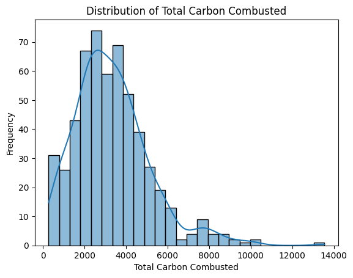

```python
sns.histplot(burned_plot_data['total_c_combusted'], kde=True)
plt.title("Distribution of Total Carbon Combusted")
plt.xlabel("Total Carbon Combusted")
plt.ylabel("Frequency")
plt.show()
```

```python
burned_plot_data[['ag_c_combusted', 'bg_c_combusted', 'total_c_combusted']].head()
```

|  | ag_c_combusted | bg_c_combusted | total_c_combusted |
| --- | --- | --- | --- |
| 0 | 0.0 | NaN | NaN |
| 1 | 0.0 | NaN | NaN |
| 2 | 0.0 | NaN | NaN |
| 3 | 0.0 | NaN | NaN |
| 4 | 0.0 | NaN | NaN |

Scatter Plot: Stand Age vs. Total Carbon Combusted

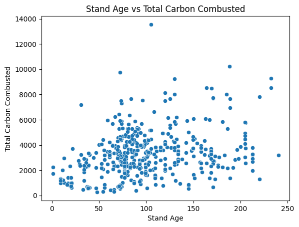

```python
# Scatter plot of stand age vs. total carbon combusted
sns.scatterplot(x='stand_age', y='total_c_combusted', data=burned_plot_data)
plt.title("Stand Age vs Total Carbon Combusted")
plt.xlabel("Stand Age")
plt.ylabel("Total Carbon Combusted")
plt.show()
```

Average Total Carbon Combusted by Ecoregion

```python
ecoregion_combustion = burned_plot_data.groupby('ecoregion_name_l2')['total_c_combusted'].mean()
print(ecoregion_combustion)
```

```
ecoregion_name_l2
Alaska Boreal Interior    2972.842667
Boreal Cordillera         3514.694537
Boreal Plains             3368.019094
Softwood Shield           2842.741667
Taiga Plains              3371.220566
Taiga Shield              3317.403106
Name: total_c_combusted, dtype: float64
```

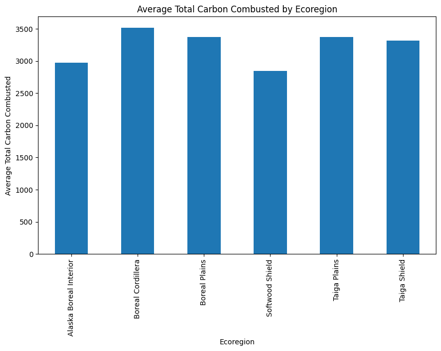

```python
# Plot the results
ecoregion_combustion.plot(kind='bar', figsize=(10, 6))
plt.title('Average Total Carbon Combusted by Ecoregion')
plt.xlabel('Ecoregion')
plt.ylabel('Average Total Carbon Combusted')
plt.show()
```

## Correlation Analysis

Correlation Heatmap for Numerical Variables

```python
# Select only numeric columns
numeric_data = burned_plot_data.select_dtypes(include=['float64', 'int64'])
```

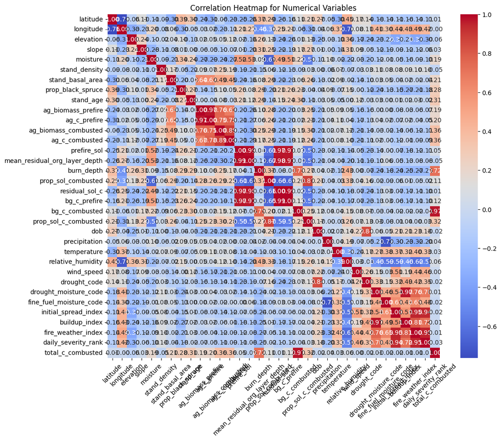

```python
# Compute correlation and plot heatmap
plt.figure(figsize=(12, 10))  # Increase figure size
sns.heatmap(numeric_data.corr(), annot=True, fmt=".2f", cmap="coolwarm")
plt.title('Correlation Heatmap for Numerical Variables')
plt.xticks(rotation=45)
plt.yticks(rotation=0)
plt.show()
```

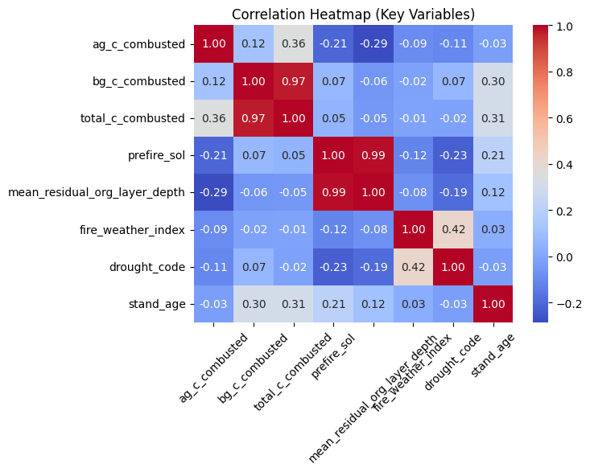

```python
#for readability:
key_vars = [
    'ag_c_combusted', 'bg_c_combusted', 'total_c_combusted',
    'prefire_sol', 'mean_residual_org_layer_depth',
    'fire_weather_index', 'drought_code', 'stand_age'
]
sns.heatmap(burned_plot_data[key_vars].corr(), annot=True, fmt=".2f", cmap="coolwarm")
plt.title('Correlation Heatmap (Key Variables)')
plt.xticks(rotation=45)
plt.show()
```

## Temporal Analysis

Trend of Total Carbon Combusted Over Time

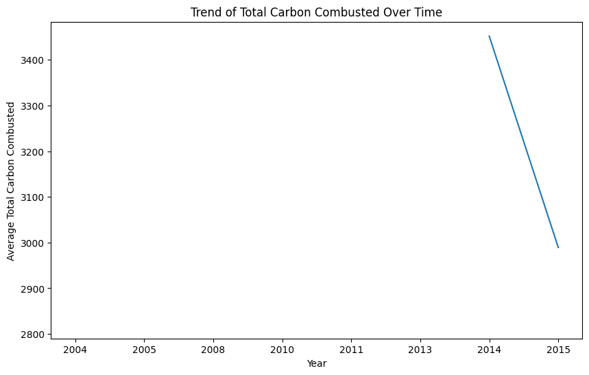

```python
# Temporal trend of total carbon combusted
temporal_trend = burned_plot_data.groupby('burn_year')['total_c_combusted'].mean()
temporal_trend.plot(kind='line', figsize=(10, 6))
plt.title('Trend of Total Carbon Combusted Over Time')
plt.xlabel('Year')
plt.ylabel('Average Total Carbon Combusted')
plt.show()
```

Trend of Fire Weather Index Over Time

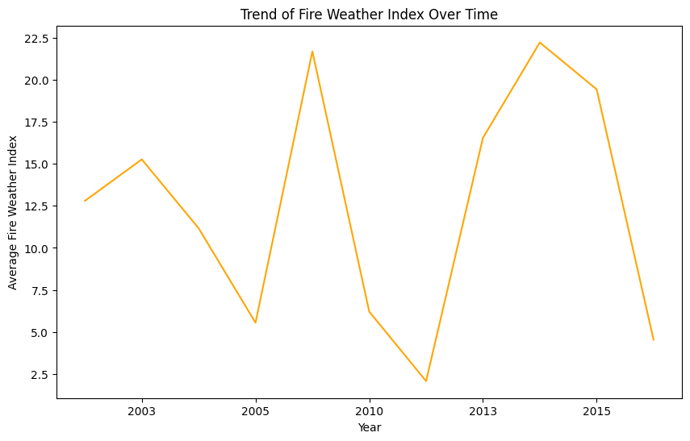

```python
# Temporal trend of Fire Weather Index
fwi_trend = burned_plot_data.groupby('burn_year')['fire_weather_index'].mean()
fwi_trend.plot(kind='line', figsize=(10, 6), color='orange')
plt.title('Trend of Fire Weather Index Over Time')
plt.xlabel('Year')
plt.ylabel('Average Fire Weather Index')
plt.show()
```

Scatter Plot: Soil Carbon vs. Total Carbon Combusted

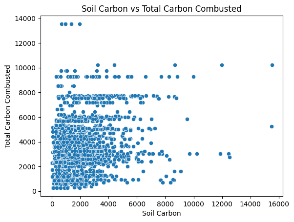

```python
# Merge burned_plot_data and soil_profile_data on 'site'
merged_data = pd.merge(burned_plot_data, soil_profile_data, on='site', how='inner')

# Correlation between soil carbon and total carbon combusted
sns.scatterplot(x='carbon', y='total_c_combusted', data=merged_data)
plt.title('Soil Carbon vs Total Carbon Combusted')
plt.xlabel('Soil Carbon')
plt.ylabel('Total Carbon Combusted')
plt.show()
```

Average Stand Age by Ecoregion

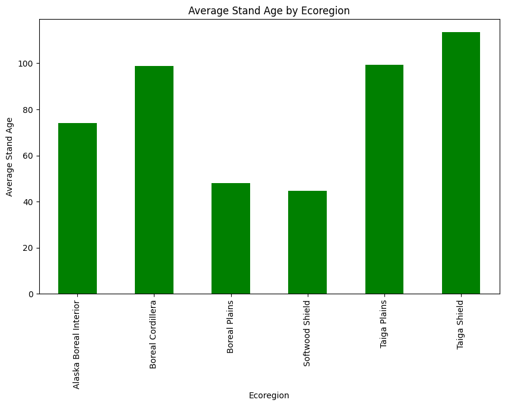

```python
# Average stand age by ecoregion
avg_stand_age = burned_plot_data.groupby('ecoregion_name_l2')['stand_age'].mean()
avg_stand_age.plot(kind='bar', figsize=(10, 6), color='green')
plt.title('Average Stand Age by Ecoregion')
plt.xlabel('Ecoregion')
plt.ylabel('Average Stand Age')
plt.show()
```

Density Plot of Fire Weather Index

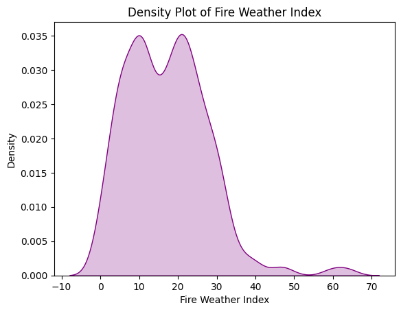

```python
sns.kdeplot(burned_plot_data['fire_weather_index'], fill=True, color='purple')
plt.title('Density Plot of Fire Weather Index')
plt.xlabel('Fire Weather Index')
plt.ylabel('Density')
plt.show()
```

Correlation Heatmap for Soil and Fire Characteristics

```python
# Define relevant columns
relevant_columns = [
    'carbon', 'fine_bulk_density', 'coarse_bulk_density',
    'total_c_combusted', 'stand_age', 'fire_weather_index'
]
```